# IF ANIMAL TRAPPED…

Irshaad Vawda | 19 February 2020

(When viewing from mobile, swipe left to see the "footnotes" in the right-hand margin)

# Sociology and the best TV ever made

For someone that’s borderline Extremely Online, the lack of a Twitter header image is pretty poor form on my part. Yet, thousands of tweets and likes later, I was still header-less. What does one even write or draw or make for a header? In an age where [Tik Tokkers go from relative obscurity to celebrities in months](https://www.vox.com/the-goods/2019/10/2/20891915/tiktok-famous-teenagers-haley-sharpe-yodeling-karen), this type of decision seems marginally important to one’s career.

Checking Twitter 74 times a day is only borderline right? [Here’s a nice piece](https://www.dailydot.com/unclick/what-does-it-mean-to-be-extremely-online/) that explains my behaviour

The irony of writing this on a stand alone blog like it’s 1999 is not lost on me

And then, as sometimes happens in life, I wondered across the [Twitter profile of one Cabel](https://twitter.com/cabel), who with 78k followers has a simple block of text in his header. It reads “hello.” and while I don’t know much about Cabal, I think it’s beautiful. And so I decided I would write-up some lovely text of my own as a header image.

At the same time, I’ve been re-watching The Wire, season 4. Now, in my not-so-important-yet-still-not-humble view, The Wire is the best TV ever made. Some rate The Sopranos higher, and while that is a respectable view, it has the distinct downside of being wrong. [Here, from Vulture,](https://www.vulture.com/2012/03/drama-derby-finals-the-wire-vs-the-sopranos.html) is a good head to head of the two.

I’m not alone in holding this view however. Here’s [the BBC backing me up](http://www.bbc.com/culture/story/20180412-how-the-wire-became-the-greatest-tv-show-ever-made), as well as [Jacobin here](https://jacobinmag.com/2018/03/the-wire-david-simon-hbo) bearing testimony to the amazing feat that The Wire is. The Guardian does a good job [here](https://www.theguardian.com/tv-and-radio/2018/mar/06/the-wire-10-years-on-we-tore-the-cover-off-a-city-and-showed-the-american-dream-was-dead) too of singing similar praise. But why all this praise? Well, perhaps it’s because The Wire was just really great sociology, packaged for the TV screen. [Real life sociologists](https://www.theguardian.com/society/joepublic/2009/nov/27/the-wire-social-science-fiction), not the play-play type like me, [have taught The Wire and held conferences](https://slate.com/culture/2010/03/why-are-professors-at-harvard-duke-and-middlebury-teaching-courses-on-david-simon-s-the-wire.html) in its name (the highest honour the Academy can seemingly bestow upon a TV show?)

or “kali-kali” as I grew up saying

In season 4 of this masterpiece, one of the threads that the story-line weaves around is the “vacants” - empty buildings and houses that a particular drug kingpin hides dead bodies in. These “vacants” are boarded up, and occasionally have the following text written on them: “IF ANIMAL TRAPPED CALL 410-844-6286.” The pictures below are still-shots I took from the series itself. This image is one that is used repeatedly in the season (and I think elsewhere in the show), in the way only The Wire could.

Featuring none other than [Lester Freamon](https://en.wikipedia.org/wiki/Lester_Freamon) and [Bunk Moreland](https://en.wikipedia.org/wiki/Bunk_Moreland)!

For me, this is exactly what Tom Brookes, writing on the LSE blog, meant when he noted the The Wire provides the ’visual equivalent of Geertz’s ethnographic “thick description.”’See End Note 1 for more.

Figure 1: From the Series: If Animal Trapped…

[figure not shown]

The phrase is poetic and laden with all manner of deeper meaning. Take these Reddit threads [here](https://www.reddit.com/r/TheWire/comments/xs5pj/if_animal_trapped_call_4108446286/) and [here](https://www.reddit.com/r/TheWire/comments/pdusv/if_animal_trapped_call_4108446286_baltimore/) that casually explore some of the interpretations. The people of the internet have even turned it into [merchandise](https://www.redbubble.com/people/lordbiro/works/11439006-the-wire-if-animal-trapped?p=lightweight-hoodie), a fairly ironic development.

[figure not shown]

For me, the phrase depicts the state of socio-technical system design in all it’s glory, which is to say, it lays bear the truth of the meagre progress. Creating a phone hotline to deal with just one symptom of a far larger broader societal failure is emblematic of “technology solutionism” . It reflects the broken nature of so many institutions, and the impulse to fix complex social problem with a tech band-aid.

In block letters, the phase is printed on boards that are used in the series to hide the bodies of murder victims. The juxtaposition of this odd wording with the broader storyline, reveals the utter futility of this solution - the city is rife with murder and drug related violence, how could it ever hope to sucessfully run a telephonic system dealing with the nitty-gritty the accidental trapping of animals?

And yet, this is what we do repeatedly as engineers and designers. We reach too quickly for the seemingly simpler solution, without doing the difficult and often fruitless work of digging deeper behind our tech interventions and looking at the sociological dimension. Too much traffic? More roads. Too much carbon emission? Geo-engineering, lots of carbon off-sets, and maybe solar everywhere!. And so on.

I’m a big fan of renewable energy, but there’s much, more to a just energy transition than simply building billions of solar panels

So, when an animal is trapped in vacant building in a drug ridden city, maybe you shouldn’t set up a telephone system that will never work. Maybe you should…design better socio-technical systems instead.

# Everything is a socio-technical systems.

That really is the true story of how I ended up with the image below as my twitter header image.

But there is still something to be said about the design of this image, which although inspired by Cabal, does many things a little differently. To begin with, let’s talk about the Type.

Figure 3: Irshaad Twitter Header

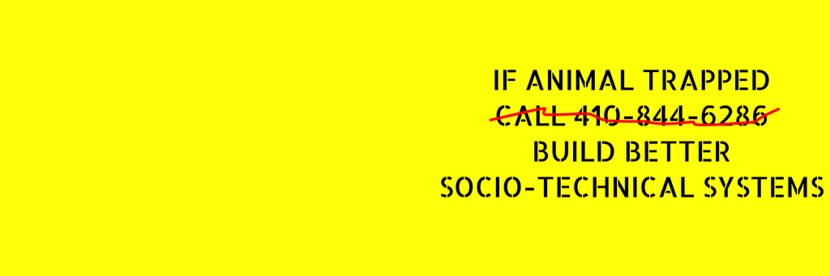

I was watching Netflix’s [“Abstract: The Art of Design”](https://www.netflix.com/za/title/80057883) and Episode 6 is about [Paula Scher](https://en.wikipedia.org/wiki/Paula_Scher) from the famous firm [Pentagram](https://www.pentagram.com/). Somewhat embarrassingly, only having watched this episode and fairly late in life, have I come to appreciate the strong socio-technical nature of “brand and identity systems.” Type, or what us commoners may reductively call “font,” is both extremely technical and very social.

With this new-found appreciation, I wanted to find the original type used in The Wire for my header. A silly idea perhaps, but I wanted some “authenticity” in this header of mine. Having failed at this and wasted several hours, I settled, rather anti-climatically, for a stencil font called [Allerta Stencil](https://fonts.google.com/specimen/Allerta+Stencil) from the Google font selection.

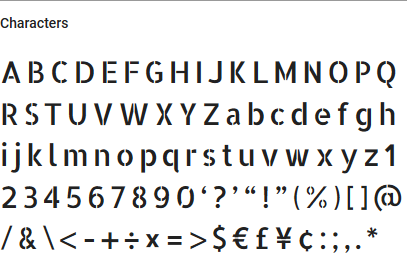

Figure 4: Allerta Stencil

I did however come across [this nice piece](https://thelawlers.com/Blognosticator/?p=749) about the history of the “stencil” typeface, again underlining the social origin of this technical communication system.

This is also a good opportunity to point out how design decisions get made. That *Everything is designed* holds true I think, even if the design decision is simply to go with the default, or easiest, or what’s been done before. But everything is, in some way and with varying effort, decided upon.

I also went with the colour yellow, which seems to me to be a very [“roaring 20s”](https://en.wikipedia.org/wiki/Roaring_Twenties) look. I wonder if I have it right. The red scratch on the other hand, was something I made haphazardly in Inkscape. I wish I could say its a sign of the nature of how complex system evolve (often haphazardly), but I sadly can’t.

“The Roaring Twenties (sometimes stylized as the Roarin’ Twenties) refers to the decade of the 1920s in Western society and Western culture. It was a period of economic prosperity with a distinctive cultural edge in the United States and Europe” - Wikipedia

Everything then, in some way or form, is a socio-technical system. Granted, some, like the political-economy of Baltimore in The Wire, are more complicated than the design of a Twitter Header image, but they’re all systems.

# The Wire in the age of Extremely Online

For all it’s acclaim and praise as a sociological masterpiece, in the age of Extremely Online, I can’t help but wonder if David Simon’s ability to reach beyond the simply apparent and reveal the deeper society behind the mundane details of life, failed him on one deliciously curious front: the so called surveillance capitalism of our modern world.

In a world where our internet is dominated by a few massive tech giants, and where the phrase [“surveillance capitalism”](https://www.theguardian.com/technology/2019/jan/20/shoshana-zuboff-age-of-surveillance-capitalism-google-facebook) has gained some popularity, I wonder if The Wire missed a trick by not exploring the nefarious capability inherent in the wire tap infrastructure used in the show (and after which the show is ostensibly named).

I, for one, would have loved to see the genius of Simon brought to bear on a story arc where a Senator leaned on the police department to spy on a Church Pastor and his congregation, as a prelude to the mountains of data Facebook collects today.

Ah well. Perfection is the enemy of progress. Or no?

# End Notes

## End Note 1: Thickness in Design?

There is a book about The Wire ( [The Wire:Truth Be Told](https://books.google.co.za/books?id=ozwbjrf3thIC&printsec=frontcover&dq=The+Wire+book&hl=en&sa=X&ved=0ahUKEwjJtevEu6HoAhWQFxQKHfBLCWsQ6AEIKTAA#v=onepage&q=The%20Wire%20book&f=false)), and the introduction is written by David Simon himself. It’s a perfectly consistent (and riveting piece) by David, which starts like this: “Swear to God, it was never a cop show.”

The epigraph used by Simon here, a quote of Lester Freamon’s from the show, is instructive: “We’re building something here…and all the pieces matter.” Chosen because of the point Simon makes a few times in this piece, which is that this was a very deliberate type of show. “A visual novel” he calls it.

In my view, Simon’s introduction essay supports a view of one [Tom Brookes on the LSE Blog](https://blogs.lse.ac.uk/researchingsociology/2018/03/26/the-wire-as-sociology/), where he writes about The Wire as sociology. Tom writes about the show: “Its cinematography favours close-ups of the fine-grained matter of everyday life – an intimate focus on heroin caps and dollar bills changing hands, public telephones being dialed, cigarettes lit – rather than panoramic cityscapes. This is the visual equivalent of Geertz’s (1975) ethnographic “thick description,” a version of what Naficy (2001) might call “tactile optics.”

It was in this description that I first learned about the concept of “thick description”, and also about the work of Clifford Geertz. I’m still reading and trying to comprehend his [1975 essay entitled “Thick Description: Towards ad Interpretive Theory of Culture”](https://en.wikipedia.org/wiki/The_Interpretation_of_Cultures) but Geertz’s work and the point Brookes makes have both helped me to understand *why* I’m a fan of the The Wire. The attention to detail, the inclusion of small, seemingly inconsequential details and artifacts, pays homage to the true complexity of the context in which The Wire is set, and in doing so paints a richer picture.

Simon’s essay talks, implicitly at least, about the detail included in the show. “We staged The Wire in a real city, with real problems” he writes, and then “those foreign to Baltimore will miss many a reference, but not, I believe, the overall sense that they are learning about a city that matters.” All of this emphasizes the point that Brooke made: that there is rich visual thickness in The Wire, that helps to characterize this as a real sociological work.

For me, the actionable takeaway, as far as it is actionable, is to learn from Simon and Geertz and ask: how might we include “thicnkess” in the design process, when designing better socio-technical systems?

# Archive of Links

Because links on the internet break, I’ve captured as many of the pieces referenced and link to in this post on the “Way Back Machine”, hosted at [archive.org](https://archive.org/).

Each URL used above is pasted below, and is followed by an archive link. So if any link breaks, search for it on this page (e.g. “https://archive.org/” ) and find the corresponding archive link.

**Click here to unfold archive links**

- https://www.dailydot.com/unclick/what-does-it-mean-to-be-extremely-online/ | [archive link](https://web.archive.org/web/20200317130440/https://www.dailydot.com/unclick/what-does-it-mean-to-be-extremely-online/)
- https://www.vox.com/the-goods/2019/10/2/20891915/tiktok-famous-teenagers-haley-sharpe-yodeling-karen | [archive link](https://web.archive.org/web/20200317190652/https://www.vox.com/the-goods/2019/10/2/20891915/tiktok-famous-teenagers-haley-sharpe-yodeling-karen)
- https://twitter.com/cabel | archive link
- https://www.vulture.com/2012/03/drama-derby-finals-the-wire-vs-the-sopranos.html | [archive link](https://web.archive.org/web/20200317190843/https://www.vulture.com/2012/03/drama-derby-finals-the-wire-vs-the-sopranos.html)
- http://www.bbc.com/culture/story/20180412-how-the-wire-became-the-greatest-tv-show-ever-made | [archive link](https://web.archive.org/web/20200317191015/http://www.bbc.com/culture/story/20180412-how-the-wire-became-the-greatest-tv-show-ever-made)
- https://jacobinmag.com/2018/03/the-wire-david-simon-hbo | [archive link](https://web.archive.org/web/20200317191046/https://jacobinmag.com/2018/03/the-wire-david-simon-hbo)
- https://www.theguardian.com/society/joepublic/2009/nov/27/the-wire-social-science-fiction | [archive link](https://web.archive.org/web/20200317191134/https://www.theguardian.com/society/joepublic/2009/nov/27/the-wire-social-science-fiction)
- https://slate.com/culture/2010/03/why-are-professors-at-harvard-duke-and-middlebury-teaching-courses-on-david-simon-s-the-wire.html | [archive link](https://web.archive.org/web/20200317191229/https://slate.com/culture/2010/03/why-are-professors-at-harvard-duke-and-middlebury-teaching-courses-on-david-simon-s-the-wire.html)
- https://en.wikipedia.org/wiki/Lester_Freamon | [archive link](https://web.archive.org/web/20200317191329/https://en.wikipedia.org/wiki/Lester_Freamon)
- (https://en.wikipedia.org/wiki/Bunk_Moreland) | [archive link](https://web.archive.org/web/20200317191419/https://en.wikipedia.org/wiki/Bunk_Moreland)
- (https://www.redbubble.com/people/lordbiro/works/11439006-the-wire-if-animal-trapped?p=lightweight-hoodie) | [archive link](https://web.archive.org/web/20200317191658/https://www.redbubble.com/people/lordbiro/works/11439006-the-wire-if-animal-trapped?p=lightweight-hoodie)
- (https://twitter.com/evgenymorozov) | [archive link](https://web.archive.org/web/20200317191802/https://twitter.com/evgenymorozov)
- (https://books.google.co.za/books?id=fdggBahA1qsC&dq=event+to+save+everything+click+here&hl=en&sa=X&ved=0ahUKEwibnPCOqaHoAhUHohQKHd6wB3cQ6AEIKTAA) | [archive link](https://web.archive.org/web/20200317191807/https://books.google.co.za/books?id=fdggBahA1qsC&dq=event+to+save+everything+click+here&hl=en&sa=X&ved=0ahUKEwibnPCOqaHoAhUHohQKHd6wB3cQ6AEIKTAA)
- (https://www.netflix.com/title/80057883) | [archive link](https://web.archive.org/web/20200317192141/https://www.netflix.com/title/80057883)
- (https://en.wikipedia.org/wiki/Paula_Scher) | [archive link](https://web.archive.org/web/20200317192158/https://en.wikipedia.org/wiki/Paula_Scher)
- (https://www.pentagram.com/) | [archive link](https://web.archive.org/web/20200317192158/https://www.pentagram.com/)
- (https://fonts.google.com/specimen/Allerta+Stencil) | [archive link](https://web.archive.org/web/20200317192206/https://fonts.google.com/specimen/Allerta+Stencil)
- (https://thelawlers.com/Blognosticator/?p=749) | [archive link](https://web.archive.org/web/20200317192225/https://thelawlers.com/Blognosticator/?p=749)
- (https://en.wikipedia.org/wiki/Roaring_Twenties) | [archive link](https://web.archive.org/web/20200317192304/https://en.wikipedia.org/wiki/Roaring_Twenties)
- (https://www.theguardian.com/technology/2019/jan/20/shoshana-zuboff-age-of-surveillance-capitalism-google-facebook) | [archive link](https://web.archive.org/web/20200317192311/https://www.theguardian.com/technology/2019/jan/20/shoshana-zuboff-age-of-surveillance-capitalism-google-facebook)
- (https://books.google.co.za/books?id=ozwbjrf3thIC&printsec=frontcover&dq=The+Wire+book&hl=en&sa=X&ved=0ahUKEwjJtevEu6HoAhWQFxQKHfBLCWsQ6AEIKTAA) | archive link
- (https://blogs.lse.ac.uk/researchingsociology/2018/03/26/the-wire-as-sociology/) | [archive link](https://web.archive.org/web/20200317192410/https://blogs.lse.ac.uk/researchingsociology/2018/03/26/the-wire-as-sociology/)
- (https://en.wikipedia.org/wiki/The_Interpretation_of_Cultures) | [archive link](https://web.archive.org/web/20200317192411/https://en.wikipedia.org/wiki/The_Interpretation_of_Cultures)
- () | archive link
- () | archive link

# References

‘Abstract: The Art of Design | Netflix Official Site’. n.d. Accessed 17 March 2020. https://www.netflix.com/za/title/80057883.

Alvarez, Rafael. 2009. *The Wire: Truth Be Told*. Simon and Schuster.

Bennett, Drake. 2010. ‘Why Are Professors at Harvard, Duke, and Middlebury Teaching Courses on David Simon’s The Wire?’ Slate Magazine. 24 March 2010. https://slate.com/culture/2010/03/why-are-professors-at-harvard-duke-and-middlebury-teaching-courses-on-david-simon-s-the-wire.html.

‘Bunk Moreland’. 2020. In *Wikipedia*. https://en.wikipedia.org/w/index.php?title=Bunk_Moreland&oldid=937859091.

Busfield, Steve. 2009. ‘The Wire: Taking Sociology Forwards? | Steve Busfield’. *The Guardian*, 27 November 2009, sec. Society. https://www.theguardian.com/society/joepublic/2009/nov/27/the-wire-social-science-fiction.

‘Cabel (@cabel) / Twitter’. n.d. Twitter. Accessed 17 March 2020. https://twitter.com/cabel.

‘Evgeny Morozov (@evgenymorozov) / Twitter’. n.d. Twitter. Accessed 17 March 2020. https://twitter.com/evgenymorozov.

‘Google Fonts’. n.d. Google Fonts. Accessed 17 March 2020. https://fonts.google.com/.

Jennings, Rebecca. 2019. ‘How TikTok Turns Regular Teens into Celebrities’. Vox. 2 October 2019. https://www.vox.com/the-goods/2019/10/2/20891915/tiktok-famous-teenagers-haley-sharpe-yodeling-karen.

Lawler, Brian. 2012. ‘The Origin of the Stencil Font’. *Thelawlers.Com* (blog). 1 July 2012. https://thelawlers.com/Blognosticator/?p=749.

‘Lester Freamon’. 2020. In *Wikipedia*. https://en.wikipedia.org/w/index.php?title=Lester_Freamon&oldid=937859031.

Morozov, Evgeny. 2013. *To Save Everything, Click Here: The Folly of Technological Solutionism*. PublicAffairs.

Naughton, John. 2019. ‘“The Goal Is to Automate Us”: Welcome to the Age of Surveillance Capitalism’. *The Observer*, 20 January 2019, sec. Technology. https://www.theguardian.com/technology/2019/jan/20/shoshana-zuboff-age-of-surveillance-capitalism-google-facebook.

‘Paula Scher’. 2020. In *Wikipedia*. https://en.wikipedia.org/w/index.php?title=Paula_Scher&oldid=942764155.

‘Pentagram — The World’s Largest Independent Design Consultancy’. n.d. Pentagram. Accessed 17 March 2020. https://www.pentagram.com/.

‘Roaring Twenties’. 2020. In *Wikipedia*. https://en.wikipedia.org/w/index.php?title=Roaring_Twenties&oldid=945427380.

Seitz, Matt Zoller. n.d. ‘The Greatest TV Drama of the Past 25 Years, the Finals: The Wire vs. The Sopranos’. Vulture. Accessed 17 March 2020. https://www.vulture.com/2012/03/drama-derby-finals-the-wire-vs-the-sopranos.html.

‘*The Interpretation of Cultures*’. 2020. In *Wikipedia*. https://en.wikipedia.org/w/index.php?title=The_Interpretation_of_Cultures&oldid=945645253.

‘“The Wire - If Animal Trapped” Lightweight Hoodie by Lordbiro’. n.d. Redbubble. Accessed 17 March 2020. https://www.redbubble.com/people/lordbiro/works/11439006-the-wire-if-animal-trapped?p=lightweight-hoodie.

‘The Wire and the World’. n.d. Accessed 17 March 2020. https://jacobinmag.com/2018/03/the-wire-david-simon-hbo.

‘The Wire as Sociology’. 2018. *Researching Sociology @ LSE* (blog). 26 March 2018. https://blogs.lse.ac.uk/researchingsociology/2018/03/26/the-wire-as-sociology/.

‘What Does It Mean To Be An Extremely Online Person?’ 2018. The Daily Dot. 29 May 2018. https://www.dailydot.com/unclick/what-does-it-mean-to-be-extremely-online/.